# Exploring the BRFSS data

### Load packages

```r
library(ggplot2)
library(dplyr)
```

### Load data

```r
load("brfss2013.RData")
```

## Part 1: Data

BRFSS (Behavioral Risk Factor Surveillance) collects state data of the US residents regarding their health issues and conditions. Various types of data regarding their physical activeness, diet intake, previous medical history, living conditions, mental health, income levels, etc. have been collected by conducting surveys via the landlines or cellular telephones. Disproportionate stratified sampling (DSS) was used for the landline survey. The data collected has 491775 rows(patient) and 330 columns(variables). We shall use this data to gain some insights about the population and infer some statistical data about our questions.

## Part 2: Research questions

**Research quesion 1:** Plotting and visualizing to see if there exists some relation between income levels and days of poor health. As income levels might play a huge role in the number of people being unwell for prolonged days.

**Research quesion 2:** The second question involves the generally known fact that daily alchohol consumption and smoking leads to heart attacks, strokes or chronic diseases. We shall look into the data provided and gain some insights to verify whether this is actually the case or does regular consumption of alchohol and smoking not have any such relation to the medical conditions mentioned.

**Research quesion 3:** Do sleep hours affect the general health of citizens? It has been claimed by many sites and surveys that less sleep causes adverse effects on the body, we shall verify this claim via a plot and summarise our data in a table as well.

## Part 3: Exploratory data analysis

```r
incm_hlth <- brfss2013 %>%
  filter(!is.na(income2),!is.na(medcost),!is.na(poorhlth)) %>%
  select(income2,medcost,poorhlth)
incm_conn <- incm_hlth %>%
  filter(poorhlth>0) %>%
  group_by(income2) %>%
  summarise(count=n(),mean_poorhlth=mean(poorhlth))
incm_conn
```

```
## # A tibble: 8 x 3
##   income2           count mean_poorhlth
##   <fct>             <int>         <dbl>
## 1 Less than $10,000 10463         17.0
## 2 Less than $15,000  9777         16.4
## 3 Less than $20,000 10199         14.6
## 4 Less than $25,000 10636         13.6
## 5 Less than $35,000 10496         12.1
## 6 Less than $50,000 11802         10.4
## 7 Less than $75,000 11699          8.98
## 8 $75,000 or more   18038          7.29
```

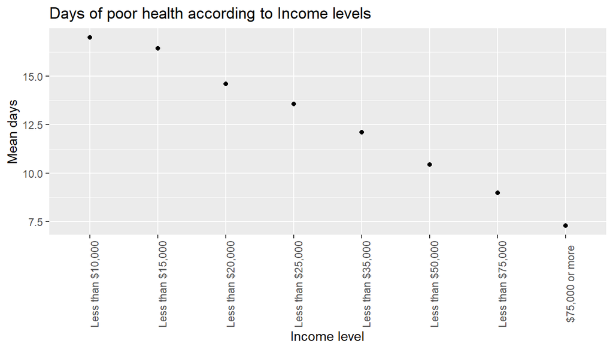

```r
ggplot (incm_conn, aes(x=income2,y=mean_poorhlth))+
  geom_point(aes(income2,mean_poorhlth))+
  theme(axis.text.x = element_text(angle = 90))+
    labs(title="Days of poor health according to Income levels",
         x="Income level", y="Mean days")
```

**Inference** This graph shows us that the mean number of days of poor health experienced by people varies drastically with their income levels and this may be due to several factors such as poor living conditions, unavailability of hospitals nearby, medical expenses being unnaffordable.

**Research quesion 2:**

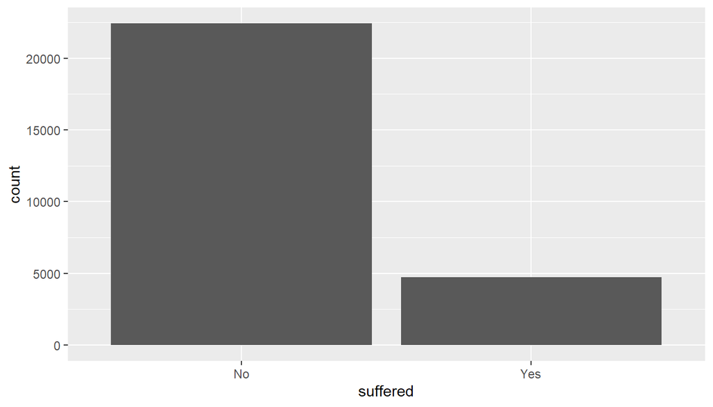

```r
alc <- filter(brfss2013, !is.na(avedrnk2), !is.na(smokday2),!is.na(cvdinfr4),!is.na(cvdcrhd4),!is.na(chccopd1)) %>%
  mutate(reg_ds = ifelse(smokday2=="Every day" & avedrnk2>0,"Yes","No")) %>%
  mutate(suffered = ifelse(cvdinfr4=="Yes" | cvdcrhd4=="Yes" | chccopd1=="Yes","Yes","No")) %>%
  filter(reg_ds=="Yes")%>%
  select(reg_ds,cvdinfr4,cvdcrhd4,chccopd1,suffered)
ggplot(data=alc,aes(x=suffered))+geom_bar()
```

```r
alc <- filter(brfss2013, !is.na(avedrnk2), !is.na(smokday2),!is.na(cvdinfr4),!is.na(cvdcrhd4),!is.na(chccopd1)) %>%
  mutate(reg_ds = ifelse(smokday2=="Every day" & avedrnk2>0,"Yes","No")) %>%
  filter(reg_ds=="Yes")%>%
  select(reg_ds,cvdinfr4,cvdcrhd4,chccopd1)

#storing counts of yes and no for heart attacks, strokes, chronic diseases in dataframes and merging them after renaming the columns so that appropriate join can be applied.
vals1 <- alc %>%
  count(cvdinfr4)
names(vals1)[names(vals1) == "cvdinfr4"] <- "Y_N"
names(vals1)[names(vals1) == "n"] <- "Heart Attack"

vals2 <- alc %>%
  count(cvdcrhd4)
names(vals2)[names(vals2) == "cvdcrhd4"] <- "Y_N"
names(vals2)[names(vals2) == "n"] <- "Stroke"

vals3 <- alc %>%
  count(chccopd1)
names(vals3)[names(vals3) == "chccopd1"] <- "Y_N"
names(vals3)[names(vals3) == "n"] <- "Chronic or pulmonary diseases"

d1 <- merge(vals1,vals2)
df<-merge(d1,vals3)
df
```

```
##   Y_N Heart Attack Stroke Chronic or pulmonary diseases
## 1  No        25878  26126                         23617
## 2 Yes         1271   1023                          3532
```

**Inference** From the table we can very clearly infer the data of the number of regular drinkers and smokers who have or have not ever been diagnosed with the three given conditions.

**Research quesion 3:**

```r
slp_hrs <- filter(brfss2013, !is.na(sleptim1), sleptim1<100)
# Creating df general health and mean of sleep time for each general health category.
hlth_slp <- slp_hrs %>%
  group_by(genhlth) %>%
  summarise(mn_sleep = mean(sleptim1))
hlth_slp
```

```
## # A tibble: 6 x 2
##   genhlth   mn_sleep
##   <fct>        <dbl>
## 1 Excellent     7.19
## 2 Very good     7.10
## 3 Good          7.04
## 4 Fair          6.90
## 5 Poor          6.74
## 6 <NA>          7.17
```

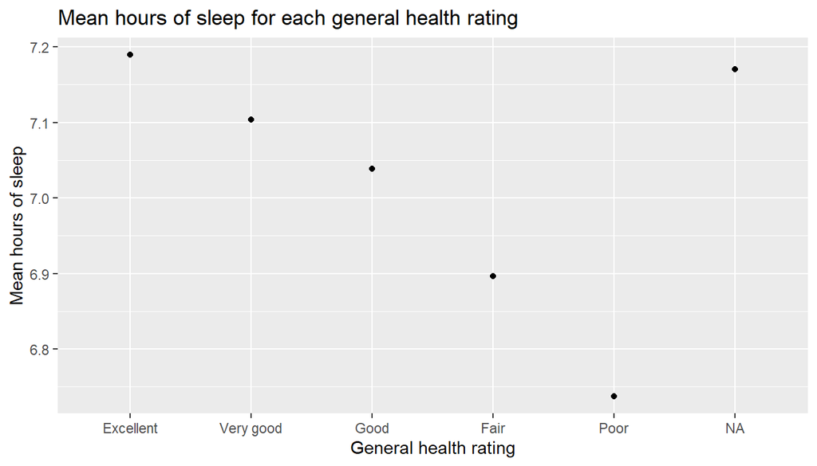

```r
ggplot(hlth_slp, aes(x=genhlth, y=mn_sleep)) +
    geom_point(aes(genhlth, mn_sleep)) +
    labs(title="Mean hours of sleep for each general health rating",
         x="General health rating", y="Mean hours of sleep")
```

**Inference** The graph very clearly portrays that the general health rating shows a depreciation with decrease in the number of average sleep hours. Although this plot may or may not be accurate owing to some other factors.